# EDA for Variables

We first import the dataset

```r
students <- read_csv("../data/student-mat.csv")
head(students)
```

```
## # A tibble: 6 x 33
##   school sex     age address famsize Pstatus  Medu  Fedu Mjob     Fjob     reason
##   <chr>  <chr> <dbl> <chr>   <chr>   <chr>   <dbl> <dbl> <chr>    <chr>    <chr>
## 1 GP     F        18 U       GT3     A           4     4 at_home  teacher  course
## 2 GP     F        17 U       GT3     T           1     1 at_home  other    course
## 3 GP     F        15 U       LE3     T           1     1 at_home  other    other
## 4 GP     F        15 U       GT3     T           4     2 health   services home
## 5 GP     F        16 U       GT3     T           3     3 other    other    home
## 6 GP     M        16 U       LE3     T           4     3 services other    reput~
## # ... with 22 more variables: guardian <chr>, traveltime <dbl>,
## #   studytime <dbl>, failures <dbl>, schoolsup <chr>, famsup <chr>, paid <chr>,
## #   activities <chr>, nursery <chr>, higher <chr>, internet <chr>,
## #   romantic <chr>, famrel <dbl>, freetime <dbl>, goout <dbl>, Dalc <dbl>,
## #   Walc <dbl>, health <dbl>, absences <dbl>, G1 <dbl>, G2 <dbl>, G3 <dbl>
```

We will also recode the variables in the dataset.

We produce two versions of the file: One where Walc is kept with 5 factors, and one where it’s transformed to a binomial variable called `Walc_bin`

We now export these to csv files

We then proceed to conduct Exploratory Data Analysis on each variable, to try to determine which variables look interesting

Here are the list of variables that are present in the data:

# Part 1: Dependent Variable

For this project, we will be focusing on `Walc`, or weekend alcohol consumption. We will treat `Walc` as a categorical variable, as it takes on values of 1-5. We aim to predict the category each student will fall in.

# Part 2: Independent Variables

There are 31 variables that are present in the dataset, that we will classify into 4 different groups:

(Note: We think variables with a ** will be significant, based on our analysis below)

**Group A: Personal Variables**

- **`sex` - The sex of the student (categorical “’F”: Female or “M”: Male)
- **`age` - The age of the students (Continuous, from 15 to 22)
- **`address` - The area that the student’s home is located (categorical “U”: Urban or “R”: Rural)
- `internet` - Internet access at home (binary: yes or no)
- `romantic` - The student is in a romantic relationship (binary: yes or no)
- **`health` - Student current health status (categorical: from 1 - very bad to 5 - very good)

**Group B: Academic Variables**

**Group C: Family Variables**

- **`famsize` - The size of the student’s family (categorical “LE3”: Less than or equal to 3 or “GT3”: Greater than or equal to 3)
- **`Pstatus` - The status of whether the parents live together or are separated. (categorical ‘A’: Alone, ‘T’: Together)
- `Medu` - The student’s mother’s education level, with 0 being non-educated, and 4 being in higher/tertiary education. (categorical)
- `Fedu` - The student’s fother’s education level, with 0 being non-educated, and 4 being in higher/tertiary education. (categorical)
- `Mjob` - The student’s mother’s current employment position and status in the workforce (categorical variable)
- `Fjob` - The student’s father’s current employment position and status in the workforce (categorical variable)
- `guardian`- The student’s guardian (categorical: ‘mother’, ‘father’ or ‘other’)
- `famsup` - Family educational support (binary: yes or no)
- **`famrel` - The quality of the student’s family relationships (categorical: from 1 - very bad to 5 - excellent)

**Group D: Other School Variables**

- **`school` - The school that the student belongs to (categorical “GP”: Gabriel Pereira or “MS”: Mousinho da Silveira)
- **`reason` - reason to choose this school (categorical: close to ‘home’, school ‘reputation’, ‘course’ preference or ‘other’)
- `traveltime`- The student’s home to school travel time (categorical: 1 - <15 min., 2 - 15 to 30 min., 3 - 30 min. to 1 hour, or 4 - >1 hour)
- `activities`- The student is doing extra-curricular activities (binary: yes or no)
- **`freetime` - The student’s amount of free time after school (categorical: from 1 - very low to 5 - very high)
- **`goout` - How often does the student go out with friends (categorical: from 1 - very low to 5 - very high)
- **`absences` - The Number of school absences (continuous: from 0 to 75)

We will now proceed to walk through these variables one by one and examine whether they are significant in predicting alcohol level

## **Group A: Personal Variables**

### Sex

This variable describes the student’s sex (binary: ‘F’ - female or ‘M’ - male)

```
## # A tibble: 2 x 2
##   sex   count
##   <chr> <int>
## 1 F       208
## 2 M       187
```

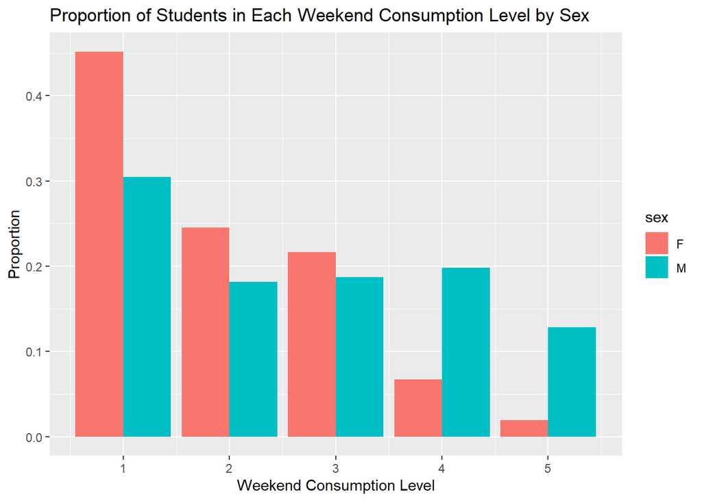

It seems that there are slightly more female students than male students in the dataset.

From these plots, it appears that males are more likely to drink more alcohol than female students. Hence, sex looks to be a significant factor in predicting weekend alcohol consumption level.

### Age

This variable describes the student’s age. It is a numeric variable ranging from 15 to 22 years old.

```
## # A tibble: 8 x 2
##     age count
##   <dbl> <int>
## 1    15    82
## 2    16   104
## 3    17    98
## 4    18    82
## 5    19    24
## 6    20     3
## 7    21     1
## 8    22     1
```

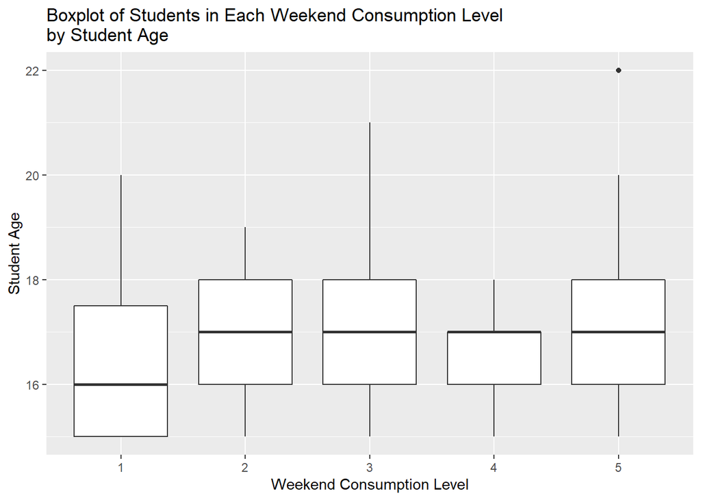

From the table output, we see that most of the students in the dataset are 15-18 years old. Additionally, it looks like the younger students have a really low alcohol consumption rate compared to the older students, so age could be a significant variable.

### Address

This variable describes the student’s home address type (binary: ‘U’ - urban or ‘R’ - rural)

```
## # A tibble: 2 x 2
##   address count
##   <chr>   <int>
## 1 R          88
## 2 U         307
```

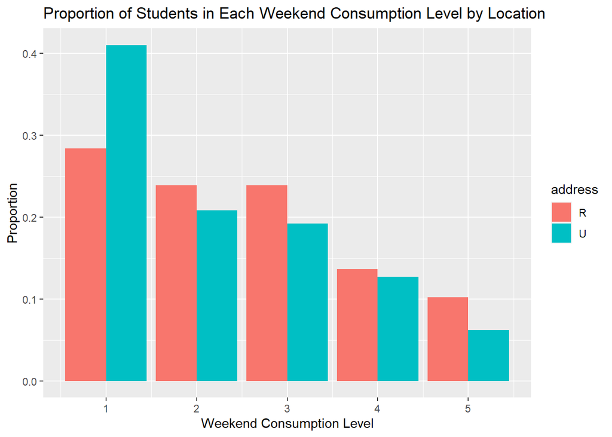

It seems that most students in the dataset live in urban areas.

From these plots, it appears that students living in rural areas are more likely to drink more alcohol than students in urban areas. Hence, address looks to be a significant factor as well.

### Internet

This is a binary variable that describes whether the student has Internet access at home (binary: yes or no)

```
## # A tibble: 2 x 2
##   internet count
##   <chr>    <int>
## 1 no          66
## 2 yes        329
```

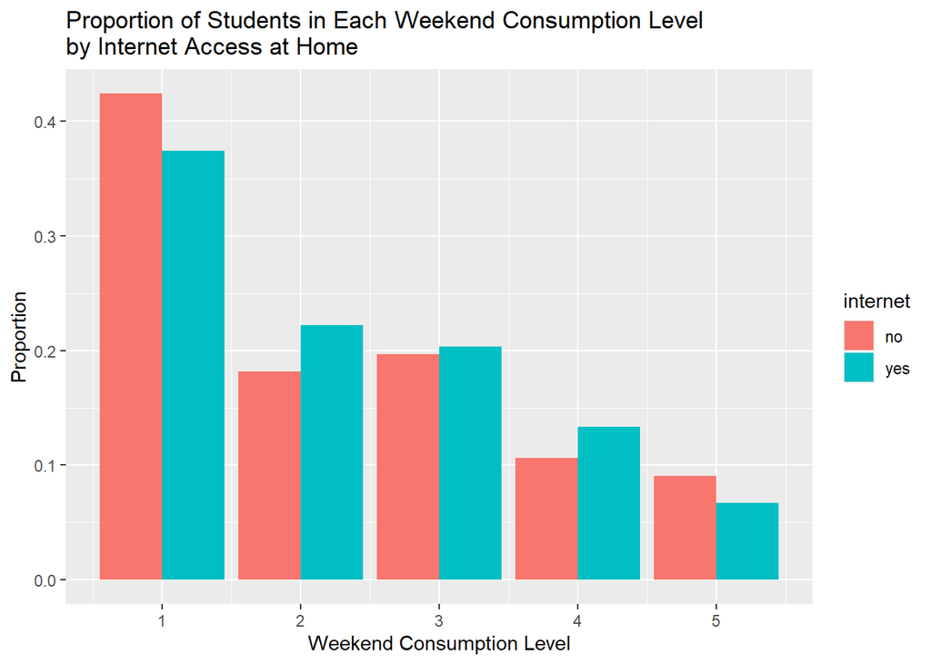

It seems like most students have internet access at home.

Additionally, it does not seem like internet access is correlated with weekend alcohol consumption level, so this variable may not be significant.

### Romantic Relationship

This is a binary variable that describes whether the student is in a romantic relationship (binary: yes or no)

```
## # A tibble: 2 x 2
##   romantic count
##   <chr>    <int>
## 1 no         263
## 2 yes        132
```

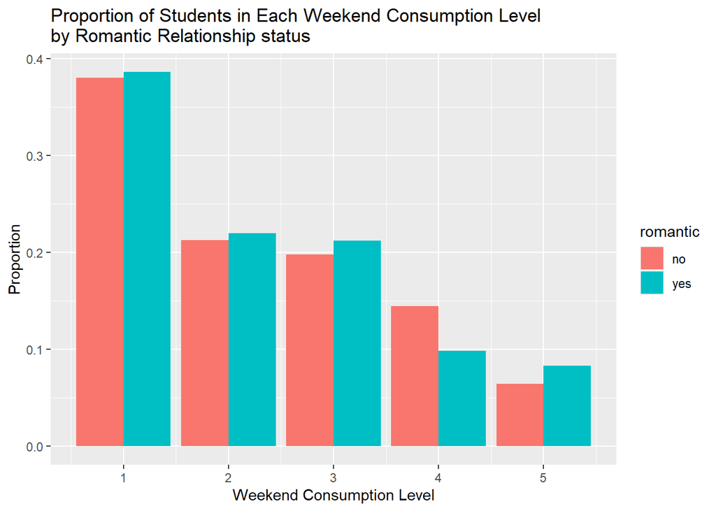

It seems like most students are not in a romantic relationship.

Additionally, it does not seem like being in a romantic relationship is correlated with weekend alcohol consumption level, so this variable may not be significant.

### Current Health Status

This is a qualitative variable that assesses the student’s current health status (Numeric: from 1 - very bad to 5 - very good)

```
## # A tibble: 5 x 2
##   health count
##    <dbl> <int>
## 1      1    47
## 2      2    45
## 3      3    91
## 4      4    66
## 5      5   146
```

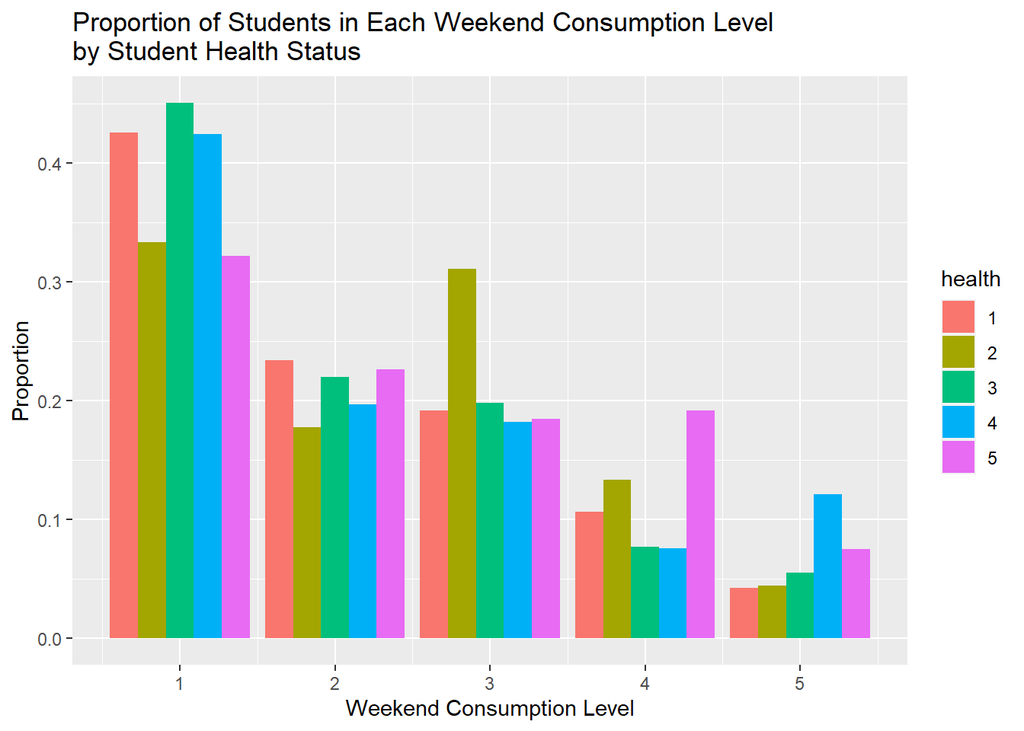

Additionally, it seems like students who have a worse health status have a lower weekend alcohol consumption than students who have better health status, so this variable could be significant.

## **Group B: Academic Variables**

### Study Time

This is a qualitative variable that counts the number of hours the student studies in a week. The number of hours is divided into 4 categories (1 - 2 hours, 2 - 5 hours, 5 - 10 hours or more than 10 hours).

```
## # A tibble: 4 x 2
##   studytime count
##       <dbl> <int>
## 1         1   105
## 2         2   198
## 3         3    65
## 4         4    27
```

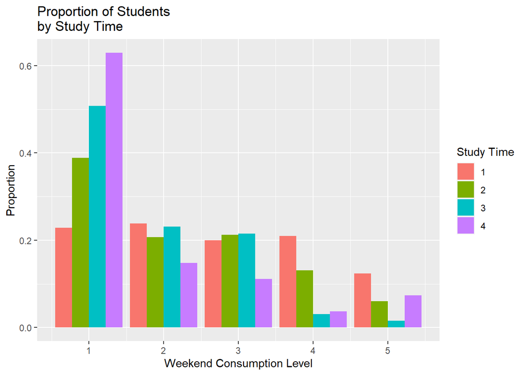

It seems most of the students study less than 5 hours a week outside of class, as they fall mostly in 1 and 2.

Additionally, it does appear that students who study more outside of class have a lower proportion of high alcohol consumption on weekends, except for the students who study the most. Therefore, this variable does appear significant.

### Past Class Failures

```
## # A tibble: 4 x 2
##   failures count
##      <dbl> <int>
## 1        0   312
## 2        1    50
## 3        2    17
## 4        3    16
```

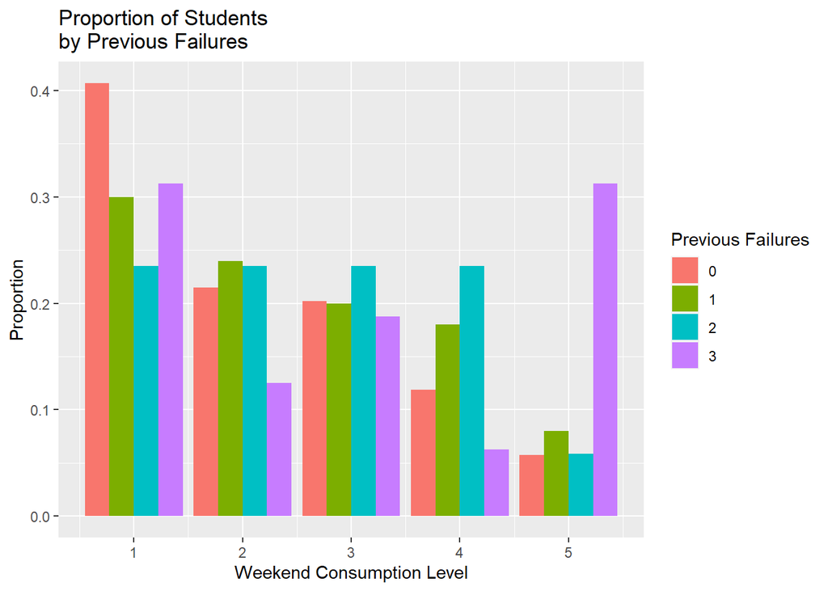

It seems like most of the students have not previously failed the class.

### Extra Educational Support

This is a qualitative variable that represents whether or not a student is receiving extra educational support (this is binary: “yes” if they are receiving extra educational support, “no” if they are not). Extra education support, here, is a very general term for academic help outside of school which includes, but is not limited to, after school tutoring with teachers and online tutoring.

```
## # A tibble: 2 x 2
##   schoolsup count
##   <chr>     <int>
## 1 no          344
## 2 yes          51
```

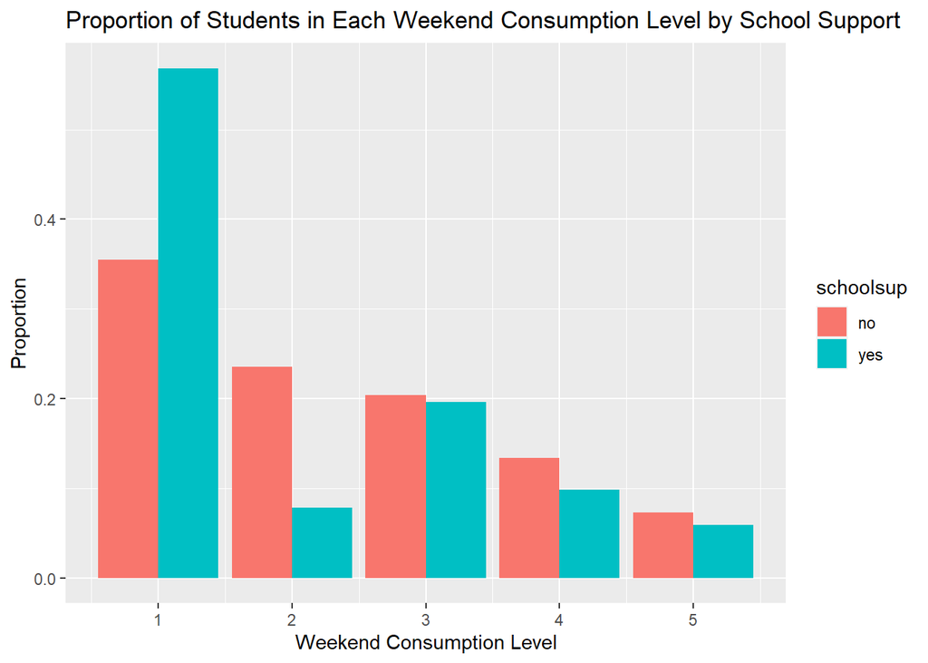

It seems like most students in the school do not receive school support.

Additionally, it seems like students who receive school support have a slightly lower weekend alcohol consumption level, so this variable may be significant.

### Extra Paid Classes

This is a qualitative variable that represents whether the student is taking extra paid classes within the course subject of Math (this is binary: “yes” if they are receiving educational support through their family, “no” if they are not).

```
## # A tibble: 2 x 2
##   paid  count
##   <chr> <int>
## 1 no      214
## 2 yes     181
```

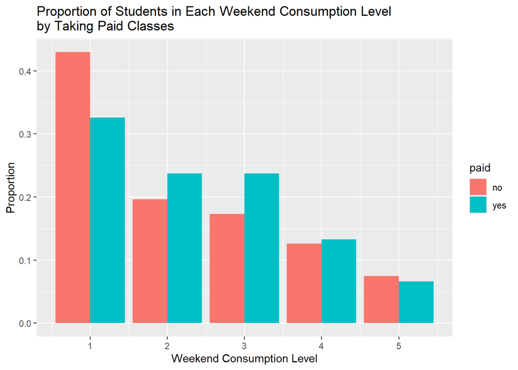

It seems like most students in the school are not taking paid classes in math.

Additionally, it seems like students taking paid classes in math have a higher weekend alcohol consumption than students who don’t, so this variable could be significant.

### Attended Nursery School

This is a qualitative variable that represents whether the student attended nursery school (this is binary: “yes” if they did, “no” if they did not). By definition, a nursery school is, “ a school for children usually under five years old.” (https://www.merriam-webster.com/dictionary/nursery%20school)

```
## # A tibble: 2 x 2
##   nursery count
##   <chr>   <int>
## 1 no         81
## 2 yes       314
```

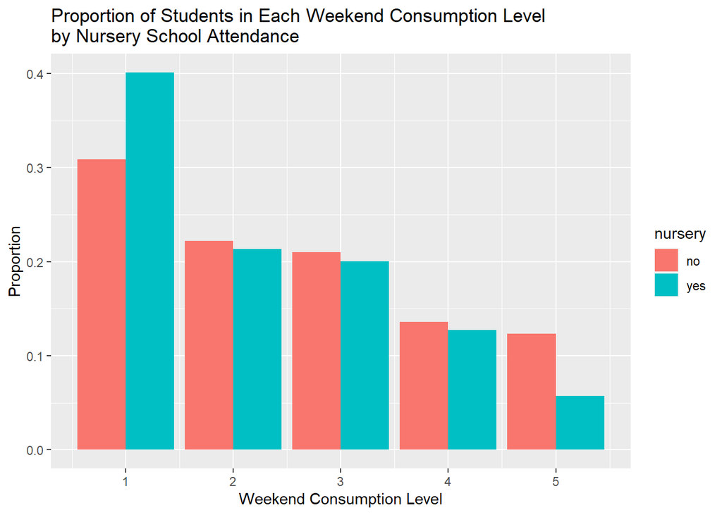

It seems like most students in the school went to nursery school.

Additionally, it seems like students who went to nursery school have a lower weekend alcohol consumption than students who don’t, so this variable could be significant.

### Wants to take Higher Education

This is a binary variable that describes whether a student wants to take higher education (binary: yes or no)

This variable could be significant, because we could predict that students who intend to pursue higher education are less likely to drink

```
## # A tibble: 2 x 2
##   higher count
##   <chr>  <int>
## 1 no        20
## 2 yes      375
```

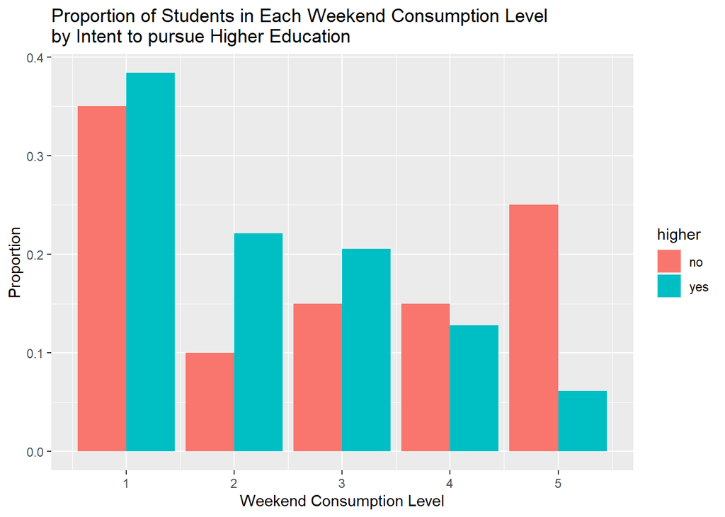

It seems like most students in the school want to pursue higher education.

Additionally, it seems like students who want to pursue higher education have a lower weekend alcohol consumption than students who don’t, so this variable could be significant.

### First Period Grade

This is a quantitative variable that shows a student’s grade for their first period ranging from 0 to 20. This is similar to, for example, the first midterm score of a university student.

```
##    vars   n  mean   sd median trimmed  mad min max range skew kurtosis   se
## X1    1 395 10.91 3.32     11    10.8 4.45   3  19    16 0.24    -0.71 0.17
```

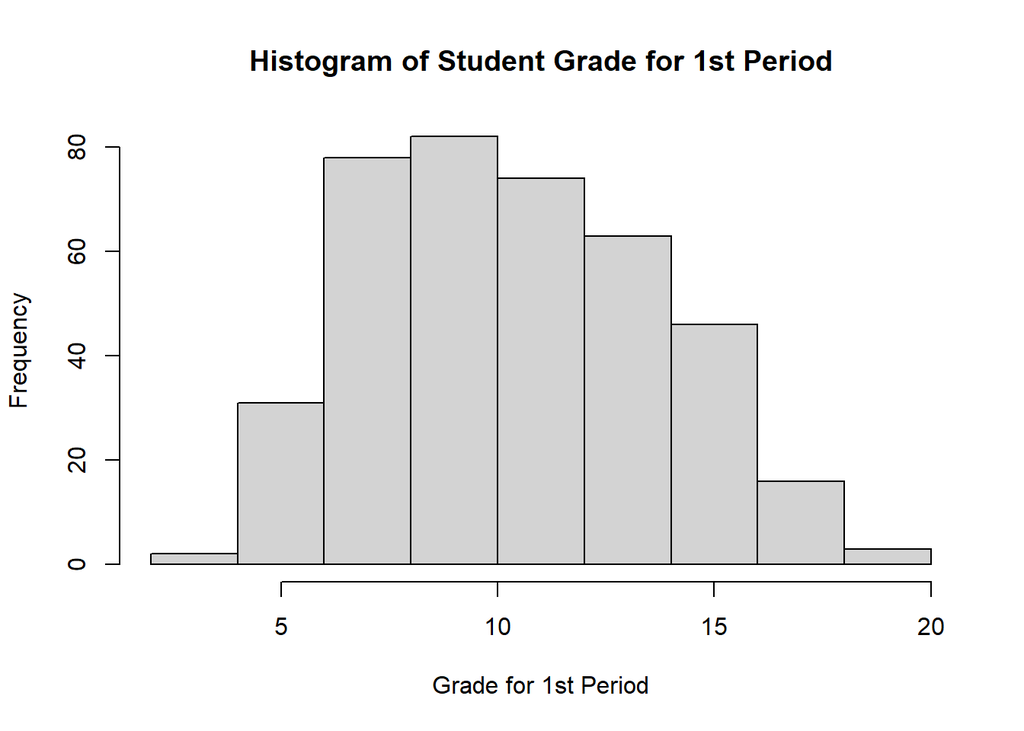

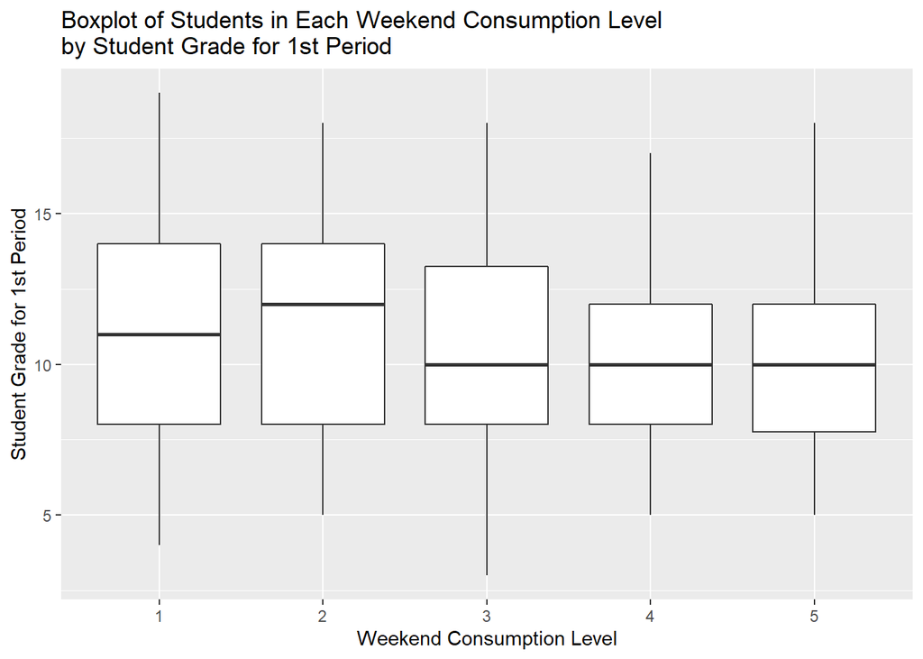

From the histogram, the student’s First period grades look pretty normally distributed.

From the boxplots above, we see that a higher weekend alcohol consumption level is related to lower median student grades for First period, indicating that this could be a significant variable.

### Second Period Grade

This is a quantitative variable that shows a student’s grade for their second period ranging from 0 to 20. This is similar to, for example, the second midterm score of a university student.

```
##    vars   n  mean   sd median trimmed  mad min max range  skew kurtosis   se
## X1    1 395 10.71 3.76     11   10.84 2.97   0  19    19 -0.43     0.59 0.19
```

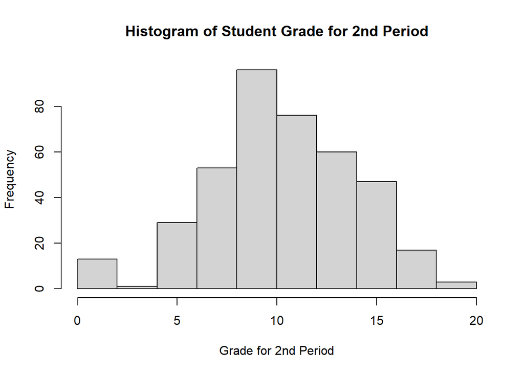

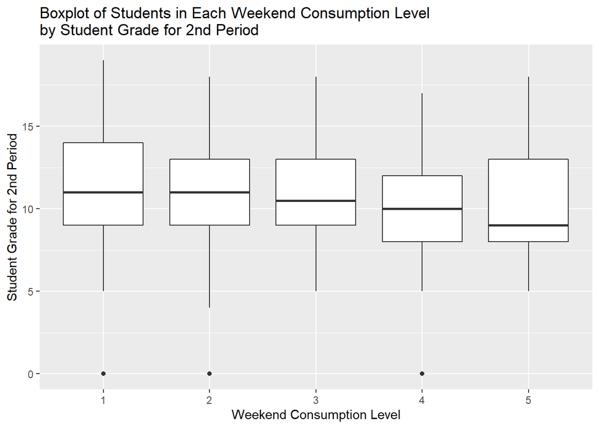

From the histogram, the student’s second period grades look pretty normally distributed.

From the boxplots above, we see that a higher weekend alcohol consumption level is related to lower median student grades for second period, indicating that this could be a significant variable.

### Final Period Grade

This is a quantitative variable that shows a student’s grade for their final period ranging from 0 to 20. This is similar to, for example, the final exam score of a university student.

```
##    vars   n  mean   sd median trimmed  mad min max range  skew kurtosis   se
## X1    1 395 10.42 4.58     11   10.84 4.45   0  20    20 -0.73     0.37 0.23
```

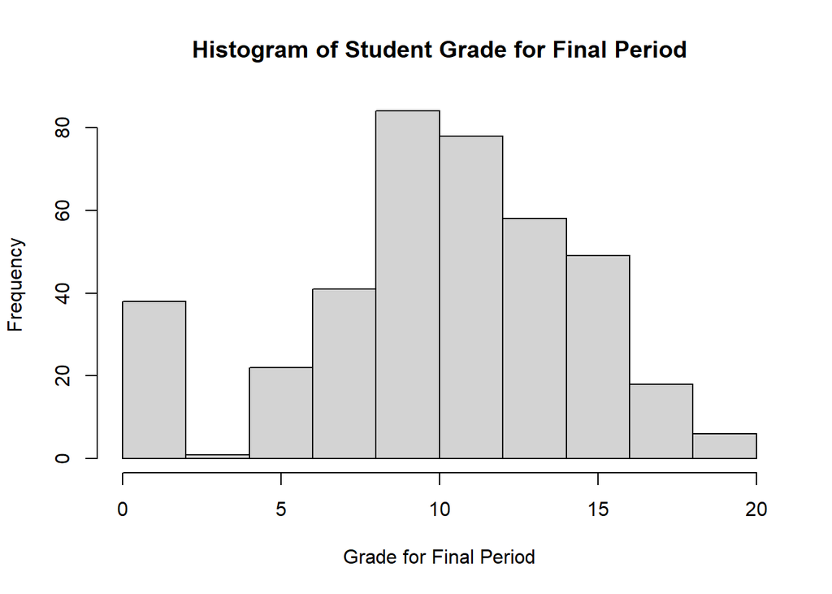

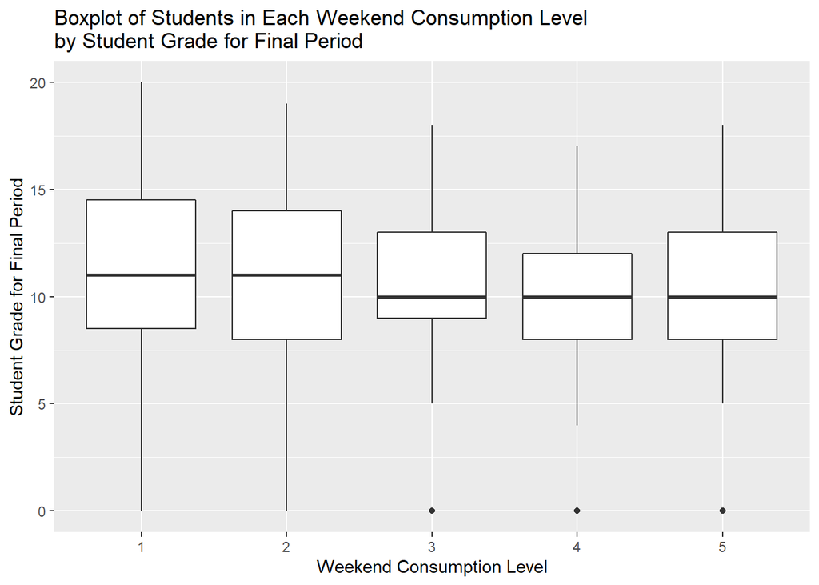

From the boxplots above, we see that a higher weekend alcohol consumption level is related to lower median student grades for final period, indicating that this could be a significant variable, but not as much as G1 and G2.

## **Group C: Family Variables**

### Family Size

This variable describes the student family size (binary: ‘LE3’ - less or equal to 3 or ‘GT3’ - greater than 3)

```
## # A tibble: 2 x 2
##   famsize count
##   <chr>   <int>
## 1 GT3       281
## 2 LE3       114
```

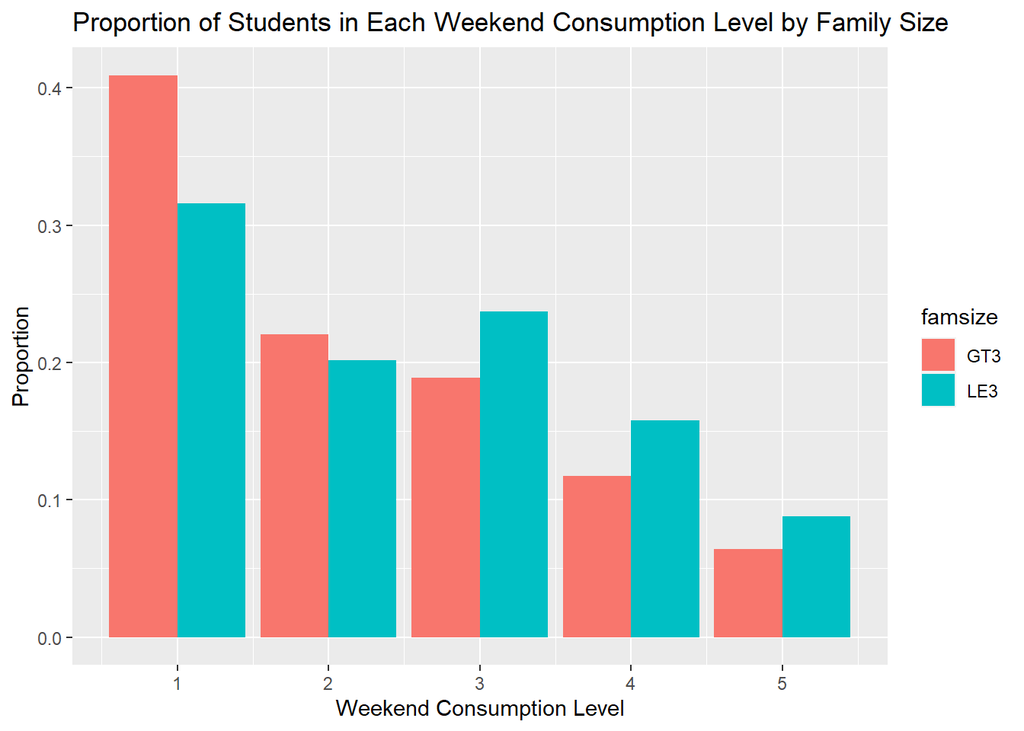

From these plots, it appears that students who have a smaller family size are more likely to drink more alcohol than students who have a larger family size. Hence, famsize looks to be a significant factor as well.

### Parent’s cohabitation status

`Pstatus` is a binary variable that reflects the status of whether the parents live together or are separated. The status of parenthood can emotionally affect these student’s lives, which might influence how much alcohol they consume as a coping mechanism to their emotional trauma. (T’ - living together or ‘A’ - apart)

```
## # A tibble: 2 x 2
##   Pstatus count
##   <chr>   <int>
## 1 A          41
## 2 T         354
```

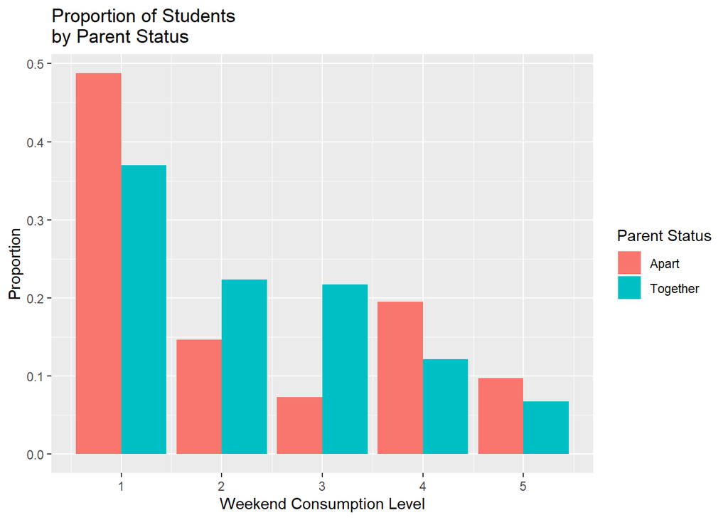

It seems that most students in the dataset have parents who live together.

### Mother’s Education

`Medu` is an ordinal-valued variable reflecting the student’s mother’s educational level, set at arbitrary levels which are mostly closely related to the levels of the mother’s education, with 0 being non-educated, and 4 being in higher/tertiary education. The mother’s education level might influence the way the student is brought up at home, which in turn might influence how much alcohol the student chooses to consume. (numeric: 0 - none, 1 - primary education (4th grade), 2 – 5th to 9th grade, 3 – secondary education or 4 – higher education)

```
## # A tibble: 5 x 2
##    Medu count
##   <dbl> <int>
## 1     0     3
## 2     1    59
## 3     2   103
## 4     3    99
## 5     4   131
```

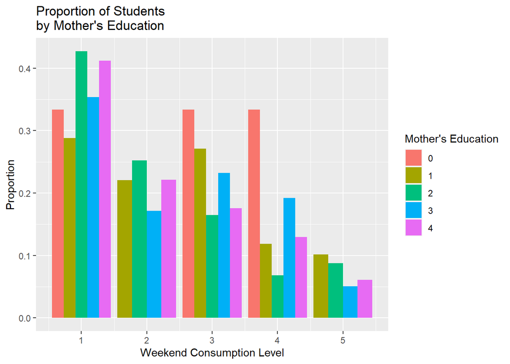

It seems that most students have mothers with high education levels.

From the plot above, it seems like all the categories have a pretty similiar alcohol consumption level, so it is not immediately clear if Mother’s Education might be a significant variable.

### Father’s Education

`Fedu` reflects the student’s father’s education level. This is an ordinal-valued variable, set at arbitrary levels which are mostly closely related to the levels of the father’s education, with 0 being non-educated, and 4 being in higher/tertiary education. The father’s education level might influence the way the student is brought up at home, which in turn might influence how much alcohol the student chooses to consume. (numeric: 0 - none, 1 - primary education (4th grade), 2 – 5th to 9th grade, 3 – secondary education or 4 – higher education)

```
## # A tibble: 5 x 2
##    Fedu count
##   <dbl> <int>
## 1     0     2
## 2     1    82
## 3     2   115
## 4     3   100
## 5     4    96
```

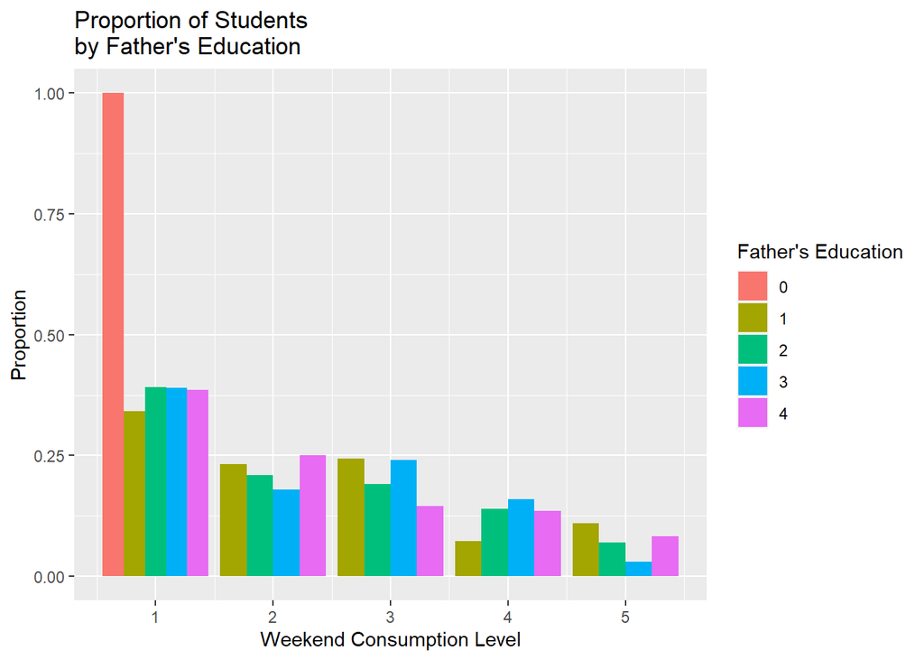

From the plot above, it seems like all the categories have a pretty similiar alcohol consumption level, so it is not immediately clear if Father’s Education might be a significant variable.

### Mother’s Current Job

The mother’s current employment position and status in the workforce. This is a nominal-valued variable, set as “teacher”, “health”, “services”, “at_home”, and “other”. While there are infinitely many jobs in the job market, these jobs are categorized as such, in order to simplify analysis in observing if the mother’s job has any influence in the student’s alcohol consumption. (nominal: ‘teacher’, ‘health’ care related, civil ‘services’ (e.g. administrative or police), ‘at_home’ or ‘other’)

```
## # A tibble: 5 x 2
##   Mjob     count
##   <chr>    <int>
## 1 at_home     59
## 2 health      34
## 3 other      141
## 4 services   103
## 5 teacher     58
```

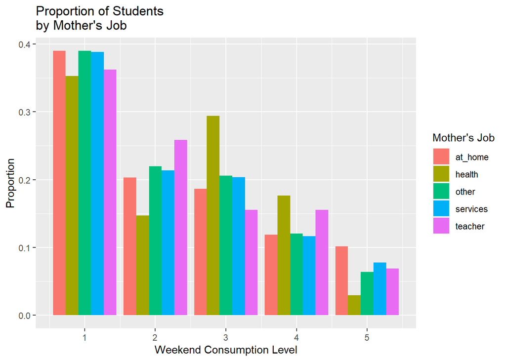

It seems most of the mothers either work in civil services or “other” jobs.

Additionally, there seems to be higher weekend alcohol consumption levels for students whose Mother’s job are at home. It is unclear if this variable is significant from just the plot alone.

### Father’s Current Job

The father’s current employment position and status in the workforce. This is a nominal-valued variable, set as “teacher”, “health”, “services”, “at_home”, and “other”. While there are infinitely many jobs in the job market, these jobs are categorized as such, in order to simplify analysis in observing if the father’s job has any influence in the student’s alcohol consumption. (nominal: ‘teacher’, ‘health’ care related, civil ‘services’ (e.g. administrative or police), ‘at_home’ or ‘other’).

```
## # A tibble: 5 x 2
##   Fjob     count
##   <chr>    <int>
## 1 at_home     20
## 2 health      18
## 3 other      217
## 4 services   111
## 5 teacher     29
```

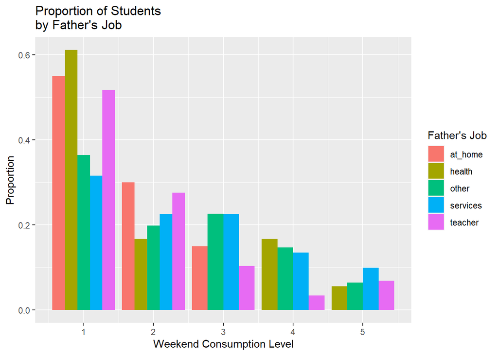

It seems most of the fathers either work in civil services or “other” jobs, similiar to the mothers.

### Student’s Guardian

This is a qualitative variable that represents the student’s guardian. The three possible options for this variable are “mother”, “father” or “other”. In the case where the student lives with a single mother or father, then “mother” or “father” would be chosen respectively. In the case where the student lives with both parents, while the data is ambiguous regarding this, it is likely that one of the parents is chosen to be the guardian. Finally, ‘other’ is chosen if neither the student’s mother or father is their primary guardian.

```
## # A tibble: 3 x 2
##   guardian count
##   <chr>    <int>
## 1 father      90
## 2 mother     273
## 3 other       32
```

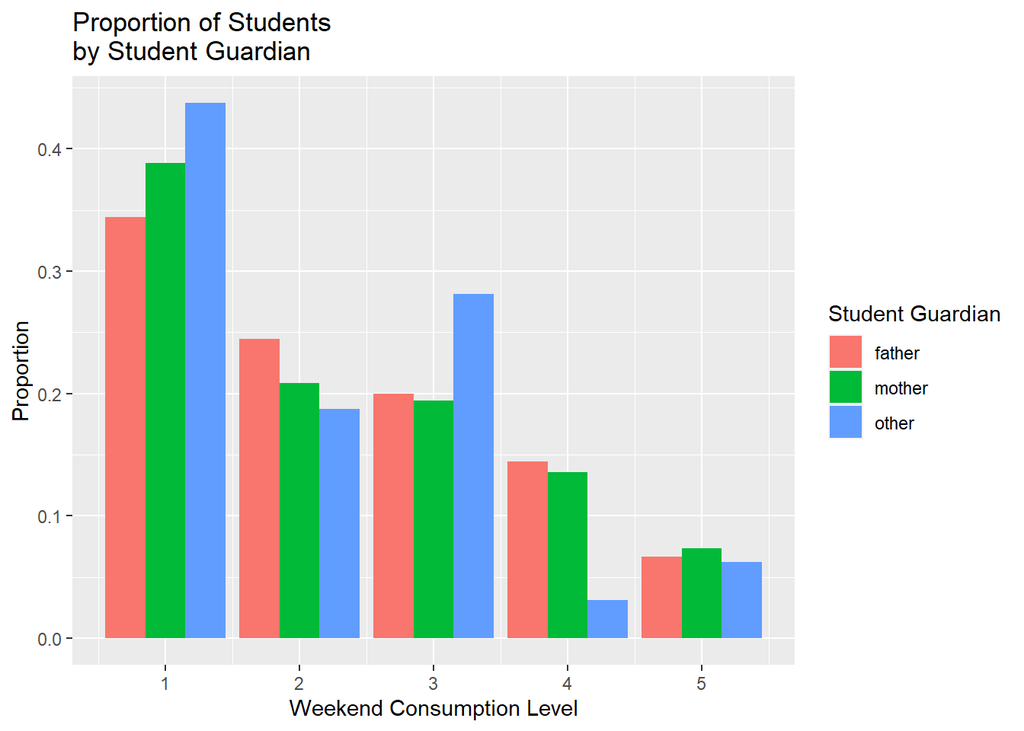

It seems most of the students have a mother as their guardian.

There does not seem to be any significant difference the groups in terms of alchohol consumption, so this variable may not be useful.

### Educational Support Through Family

This is a qualitative variable that most likely represents whether or not a student is receiving educational support through their family (this is binary: “yes” if they are receiving educational support through their family, “no” if they are not)

```
## # A tibble: 2 x 2
##   famsup count
##   <chr>  <int>
## 1 no       153
## 2 yes      242
```

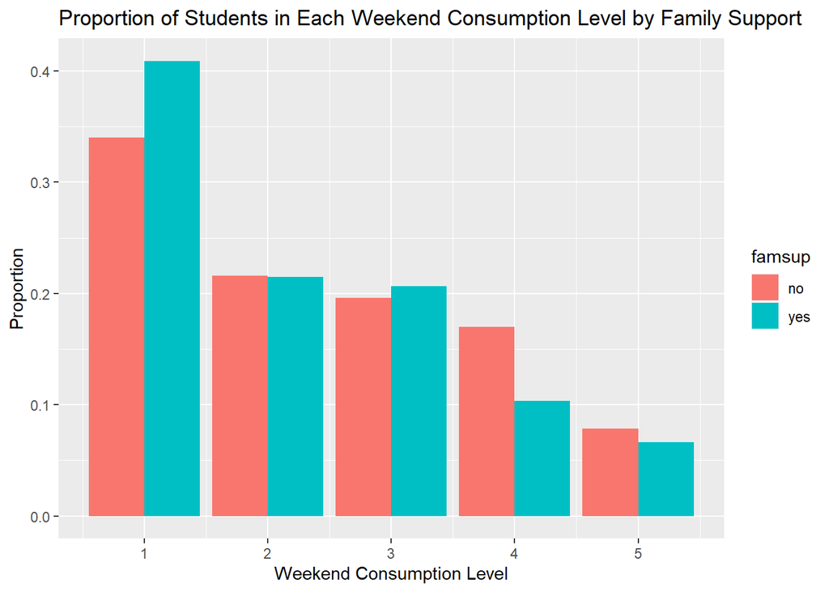

It seems like most students in the school have good family support.

Additionally, it does not seem like family support is correlated with weekend alcohol consumption level, so this variable may not be significant.

### Quality of Family Relationships

This is a qualitative variable that describes the quality of family relationships (numeric: from 1 - very bad to 5 - excellent)

```
## # A tibble: 5 x 2
##   famrel count
##    <dbl> <int>
## 1      1     8
## 2      2    18
## 3      3    68
## 4      4   195
## 5      5   106
```

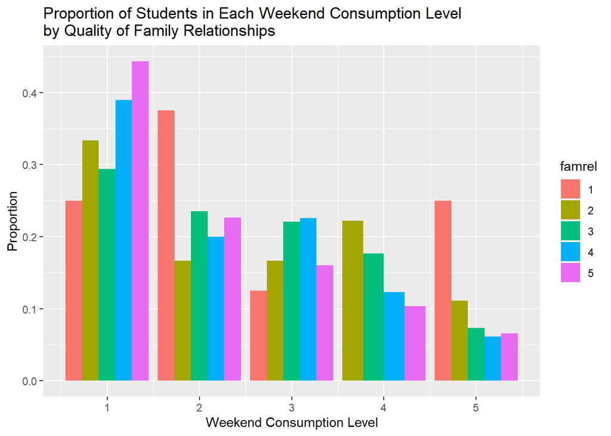

It seems like most students in the school have good family relationships.

Additionally, it seems like students who have better family relationships have a lower weekend alcohol consumption than students who don’t, so this variable could be significant.

## **Group D: Other School Variables**

### School

This variable describes the student’s school (binary: ‘GP’ - Gabriel Pereira or ‘MS’ - Mousinho da Silveira)

```
## # A tibble: 2 x 2
##   school count
##   <chr>  <int>
## 1 GP       349
## 2 MS        46
```

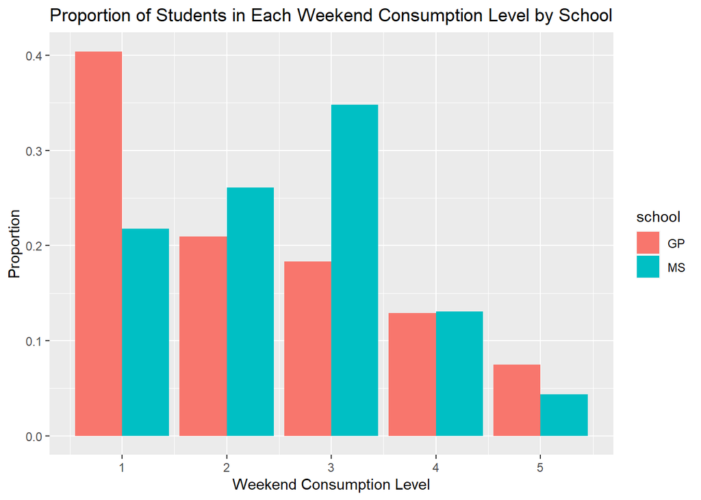

It seems that there are more students studying at Gabriel Pereira (GP) secondary school than Mousinho da Silveira (MS) secondary school.

If we look at the barplot above, we observe that for the weekend consumption levels, it looks like students in the MS secondary school have a higher consumption level on average than GP high school. Hence, school looks to be a significant factor.

### Reason to choose this school

A qualitative variable that depicts the reason a student goes to their school. There are 4 options for this variable: “home” , “reputation”, “course”, and “other”. “Home” suggests that a student chose their school because it is close to their home. “Reputation” suggests that a student chose their school because of the school’s reputation. “Course” suggests that a student chose their school because due to their course preferences. Finally, “other” is chosen if the main reason a student goes to their school is not one of the three options above.

```
## # A tibble: 4 x 2
##   reason     count
##   <chr>      <int>
## 1 course       145
## 2 home         109
## 3 other         36
## 4 reputation   105
```

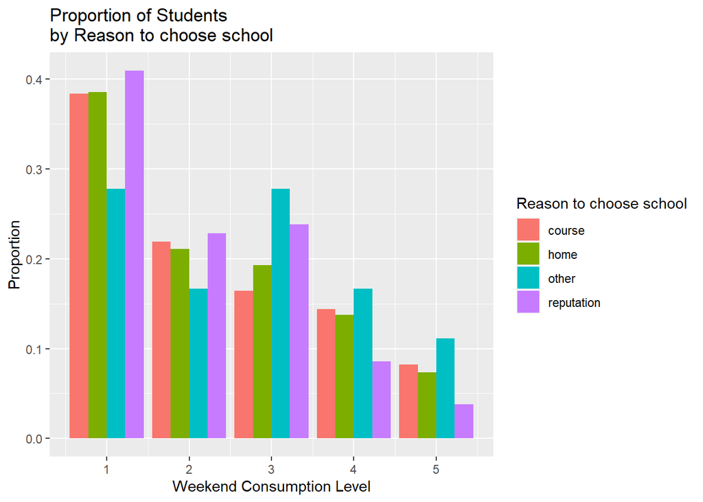

It seems most of the students chose the school because of the course, but home and reputation follow closely behind.

Additionally, there seems to be higher weekend alcohol consumption levels for students who chose ‘other’ as their reason for going to their school, whereas students who chose the school for reputation have the lowest weekend alcohol consumption rates. Therefore, this variable could be significant.

### Travel Time to School

This is a quantitative variable that represents the amount of time required for a student to travel from their living space to school. However, the quantitative values does not represent a unit of time, but rather a group of time ranges. A value of 1 maps to a time range of less than 15 minutes, 2 maps to 15-30 minutes, 3 maps to 30-60 minutes, and 4 maps to greater than one hour.

```
## # A tibble: 4 x 2
##   traveltime count
##        <dbl> <int>
## 1          1   257
## 2          2   107
## 3          3    23
## 4          4     8
```

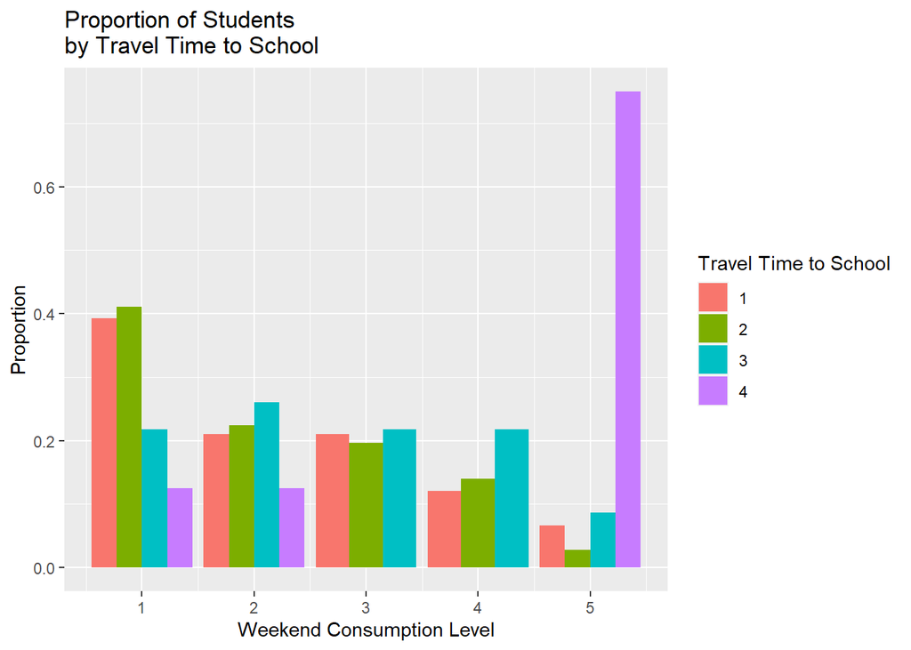

It seems most of the students live near to the school and have low travel time.

### Extracurricular Activities

This is a qualitative variable that represents whether the student is involved in extracurricular activities (this is binary: “yes” if they are, “no” if they are not)

```
## # A tibble: 2 x 2
##   activities count
##   <chr>      <int>
## 1 no           194
## 2 yes          201
```

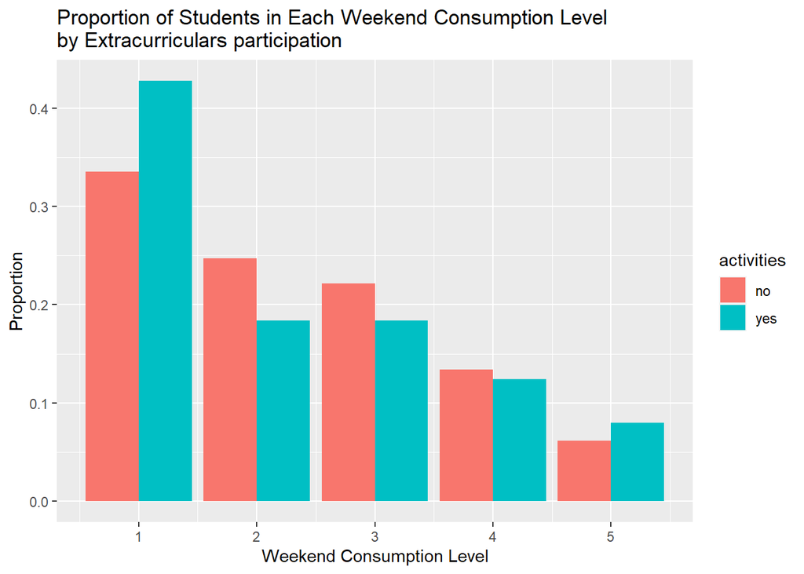

It seems like half of the students participate in extracurricular activities and half don’t.

Additionally, it does not seem like extracurricular activity participation is correlated with weekend alcohol consumption level, so this variable may not be significant.

### Free Time After School

This is a qualitative variable that describes the amount of free time the student has after school (numeric: from 1 - very low to 5 - very high)

```
## # A tibble: 5 x 2
##   freetime count
##      <dbl> <int>
## 1        1    19
## 2        2    64
## 3        3   157
## 4        4   115
## 5        5    40
```

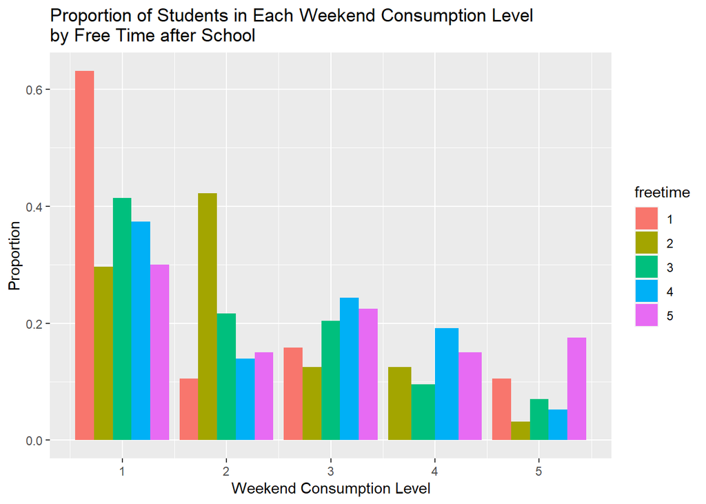

Additionally, it seems like students who have less free time after school have a lower weekend alcohol consumption than students who have more free time, so this variable could be significant.

### Go Out with Friends

A qualitative variable that describes how frequent the student goes out with friends (Numeric: from 1 - very low to 5 - very high)

```
## # A tibble: 5 x 2
##   goout count
##   <dbl> <int>
## 1     1    23
## 2     2   103
## 3     3   130
## 4     4    86
## 5     5    53
```

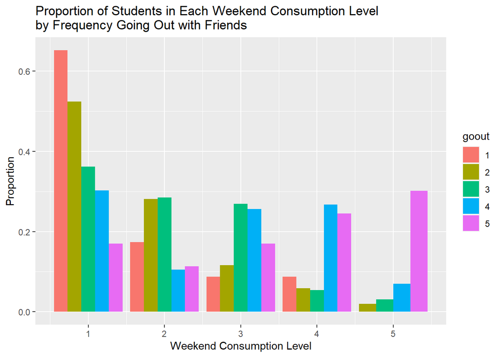

It seems like most students in the school go out with friends for a moderate amount of time.

Additionally, it seems like students who go out with friends less have a lower weekend alcohol consumption than students who go out with friends more, so this variable could be significant.

### School Absences

This is a continuous variable of the number of school absences the student has (Numeric: from 0 to 75)

```
##    vars   n mean sd median trimmed  mad min max range skew kurtosis  se
## X1    1 395 5.71  8      4    4.24 5.93   0  75    75 3.64    21.31 0.4
```

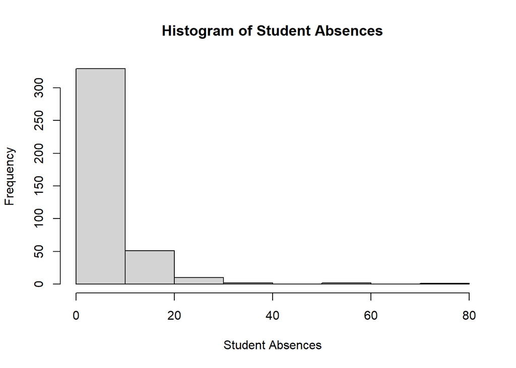

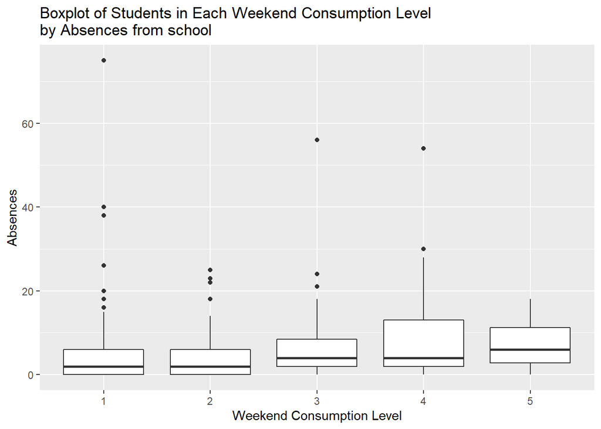

From the boxplots above, we see that a higher weekend alcohol consumption level is related to a higher median absence value for the students, indicating that this could be a significant variable.